[figure not shown]

Università degli Studi di Udine

Progetto di Fondamenti di Scienze dei Dati

# Analisi dei corrispettivi dell'azienda *Là di Cjastelan*

Dario Gaudiuso - 15 luglio 2025

# Introduzione

## L'azienda

[figure not shown]

- Piccola azienda agricola di S. Osvaldo, Udine a conduzione famigliare
- In attività storicamente dal 1870, dal 2007 nella forma attuale

## I dati

### I corrispettivi

L'Agenzia delle Entrate richiede che ogni trimestre venga consegnata un'autocertificazione riguardo i corrispettivi dei registratori di cassa telematici.

**Per ogni cassa** usata dall'azienda, bisogna dichiarare **per ogni giorno** il **totale** incassato in **ciascuna categoria di aliquota IVA**.

I prodotti venduti dall'azienda ricadono in **4 categorie**:

- **IVA 4%** -> Prodotti agricoli (latte, latticini e formaggi)
- **IVA 10% agricola** -> Carne, insaccati e yogurt
- **IVA 10% commerciale** -> Trasformati (gelato, budini, dessert, frico, tortelli, ragù...)
- **IVA 22%** -> Beni non agricoli (buste, confezioni...)

### Come sono raccolti i corrispettivi

[figure not shown]

[Cow icons created by surang - Flaticon](https://www.flaticon.com/free-icons/cow)

- fino al **2017** una singola persona compilava un'**autodichiarazione cartacea**, sommando manualmente tutti gli scontrini
- da **gennaio 2018** ad **aprile 2024** l'autodichiarazione viene consegnata in *pdf*, esportando **fogli elettronici** (Excel) in cui vengono ricopiati manualmente i corrispettivi da una singola persona

da **aprile 2024** a oggi si esporta sempre il solito modello Excel, ma con l'ausilio di un **Google Form**, compilato da chi ha svolto il mercato (il processo però **resta manuale**)

[figure not shown]

### I reparti

Sono suddivisioni del corrispettivo decise internamente dall'azienda. Nel nostro caso, tutte le casse hanno gli stessi **5 reparti**:

- **Reparto 1** -> Formaggi e latticini
- **Reparto 2** -> Carne e insaccati
- **Reparto 3** -> Yogurt
- **Reparto 4** -> Trasformati
- **Reparto 5** -> Altro (non agricolo)

### Perché studiarli?

Studiare i corrispettivi giornalieri, nella forma in cui sono raccolti, ci permetterebbe di indagare l'**andamento complessivo dell'azienda**, rispondendo a domande come:

1. L'azienda è in crescita o meno?
2. C'è stagionalità nelle vendite, cioè ci sono periodi in cui si vende meglio?
3. Quali prodotti portano più entrate?

Da **aprile 2024** abbiamo anche disponibile l'informazione su **ciascun mercato**, il che, oltre a permetterci di studiare le caratteristiche dei mercati stessi, ci permette di fare **analisi comparate** per capire se:

4. Ci sono mercati che vanno meglio degli altri?
5. Ci sono prodotti che si vendono meglio su un mercato, rispetto agli altri?

# Importazione e pulizia dei dati

## Materiale di partenza

### Cosa è stato consegnato

I dati originali sono stati consegnati in **due forme**:

- una decina di file Excel
- un link a un foglio risposte Google nel Google Drive dell'azienda

I **fogli Excel** coprono tutto l'arco **dal 2018 al primo trimestre del 2025**, ma manca il file dell'ultimo trimestre del 2024.

Il **foglio risposte** registra tutti i corrispettivi da **aprile 2024 a oggi**.

## Risultato finale

*Dataframe* dei corrispettivi:

| Data | Cassa 1 Reparto 1 | Cassa 1 Reparto 2 | Cassa 1 Reparto 3 | Cassa 1 Reparto 4 | Cassa 1 Reparto 5 | Cassa 2 Reparto 1 | Cassa 2 Reparto 2 | Cassa 2 Reparto 3 | Cassa 2 Reparto 4 | Cassa 2 Reparto 5 | Cassa 3 Reparto 1 | Cassa 3 Reparto 2 | Cassa 3 Reparto 3 | Cassa 3 Reparto 4 | Cassa 3 Reparto 5 |
| --- | --- | --- | --- | --- | --- | --- | --- | --- | --- | --- | --- | --- | --- | --- | --- |
| 2018-01-02 | 267.02 | 57.07 | 0.0 | 0.0 | 0.0 | 0.00 | 0.00 | 0.00 | 0.0 | 0.0 | 0.0 | 0.0 | 0.0 | 0.0 | 0.0 |
| 2018-01-03 | 161.85 | 74.85 | 0.0 | 0.0 | 0.0 | 0.00 | 0.00 | 0.00 | 0.0 | 0.0 | 0.0 | 0.0 | 0.0 | 0.0 | 0.0 |
| ... | ... | ... | ... | ... | ... | ... | ... | ... | ... | ... | ... | ... | ... | ... | ... |
| 2025-05-29 | 104.84 | 57.62 | 40.0 | 20.0 | 0.0 | 145.00 | 55.84 | 13.65 | 14.2 | 0.0 | 0.0 | 0.0 | 0.0 | 0.0 | 0.0 |
| 2025-05-31 | 331.05 | 35.70 | 5.1 | 31.0 | 0.0 | 395.83 | 22.10 | 30.25 | 34.2 | 0.0 | 0.0 | 0.0 | 0.0 | 0.0 | 0.0 |

2118 rows × 15 columns

*Dataframe* dei mercati:

|  | Data | Cassa | Mercato | Reparto 1 | Reparto 2 | Reparto 3 | Reparto 4 | Reparto 5 |
| --- | --- | --- | --- | --- | --- | --- | --- | --- |
| 0 | 2024-04-02 | Cassa 2 | Centro - Martedì | 116.90 | 46.00 | 3.3 | 7.23 | NaN |
| 1 | 2024-04-02 | Cassa 1 | Passons - Martedì | 150.97 | 14.07 | 20.6 | 41.74 | NaN |
| ... | ... | ... | ... | ... | ... | ... | ... | ... |
| 459 | 2025-06-10 | Cassa 2 | Passons - Martedì | 132.22 | 31.57 | 32.4 | 39.70 | NaN |
| 460 | 2025-06-11 | Cassa 2 | Villaggio - Mercoledì | 240.02 | 26.54 | 27.1 | NaN | NaN |

450 rows × 8 columns

# Analisi

## I corrispettivi

### Serie temporale

Visualizziamo la serie storica, aggregando i corrispettivi delle tre casse nel corrispettivo totale giornaliero.

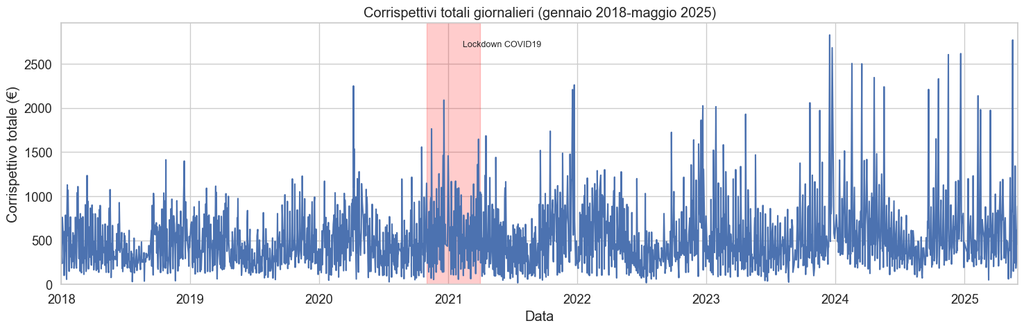

Riusciamo a intuire:

- una **stagionalità annuale**
- un **andamento stazionario** ma con picchi in crescita

### Stagionalità

Usiamo i **grafici stagionali** per verificare visivamente se c'è stagionalità nei dati.

Indaghiamo la presenza di:

- un **periodo stagionale mensile**
- un **periodo stagionale annuale**

### Stagionalità mensile

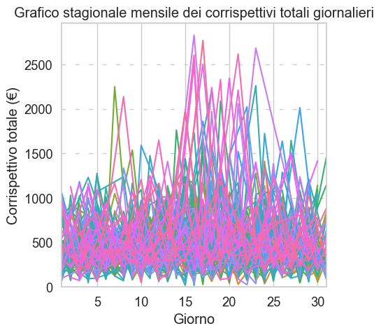

Non emerge nessun pattern evidente

### Stagionalità annuale

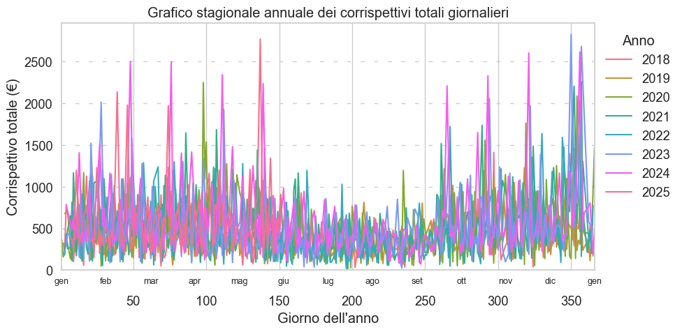

### Funzione di autocorrelazione e correlogramma

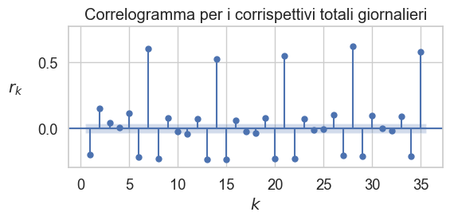

La forma del correlogramma conferma la prevalenza della componente stagionale nei dati rispetto alla componente trend e individua come periodo stagionale 7 giorni, suggerendo una stagionalità settimanale e confermando che **non c'è stagionalità mensile**.

Per far emergere la **stagionalità annuale**, dobbiamo calcolare la ACF ricampionando i dati mensilmente: passiamo dai totali giornalieri ai totali mensili.

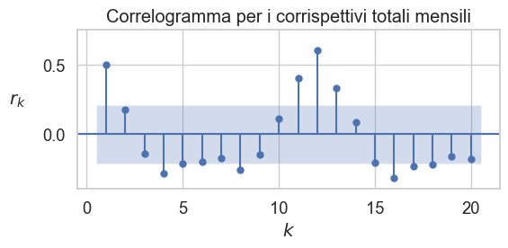

Anche qui viene individuato come periodo stagionale 12 mesi, **confermando la stagionalità annuale** ipotizzata.

Il valore di $r_1$ indica che mesi successivi correlano molto, suggerendo che non ci sono mai brusche inversioni di tendenza nei dati. La correlazione negativa di $r_4$ ci informa sul fatto che, di solito, le valli sono a distanza di 4 mesi dai picchi.

### Entrate per categoria di prodotto

L'analisi di questo tipo è, purtroppo, fortemente ostacolata dal fatto che, per alcuni periodi, i corrispettivi del Reparto 3 vengono registrati nel Reparto 2.

Lavoriamo, allora, solo sulla frazione dei dati dove abbiamo la distinzione tra tutti i reparti (57% dei dati raccolti).

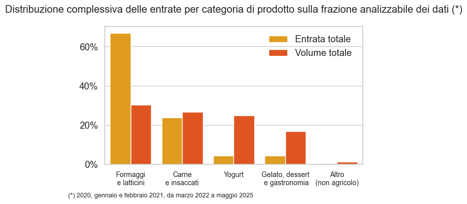

I prodotti che incidono di più sulle entrate sono di gran lunga formaggi e latticini.

La carne pesa meno di quello che, intuitivamente, saremmo portati a credere, ma comunque ha un grosso peso.

Lo yogurt viene venduto molto di più della gastronomia ma porta meno entrate.

## I mercati

Dividiamo i mercati in due categorie:

- i **mercati periodici**, che si svolgono regolarmente ogni settimana
- gli **eventi**, che sono mercati fatti *una tantum* in corrispondenze di fiere o festività

### Comparazione dei mercati periodici

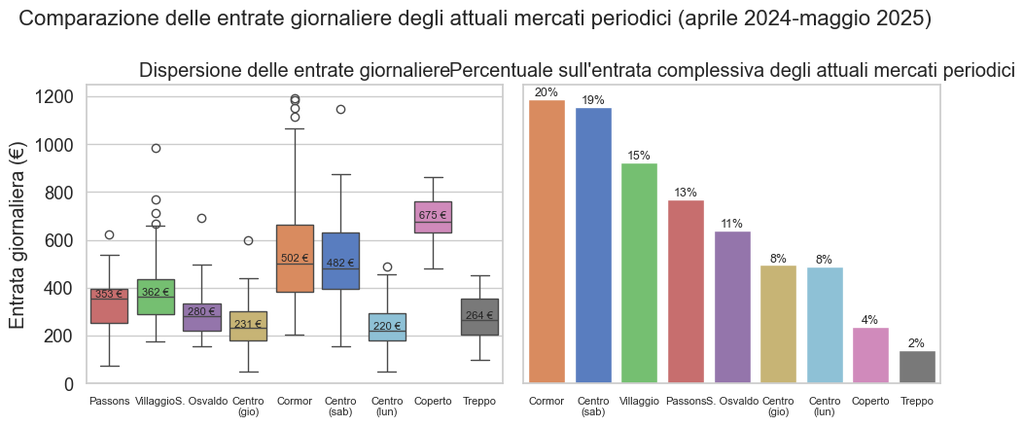

È rassicurante vedere che gli outlier nella distribuzione delle entrate giornaliere sono tutti verso l'alto.

Il mercato migliore di tutti sembra essere il mercato coperto.

Tra quelli settimanali, il mercato al parco del Cormor e il mercato in centro di sabato sono i migliori, col primo che porta un po' di più ma è molto più scostante.

I mercati in centro infrasettimanali sembrano, invece, essere i peggiori.

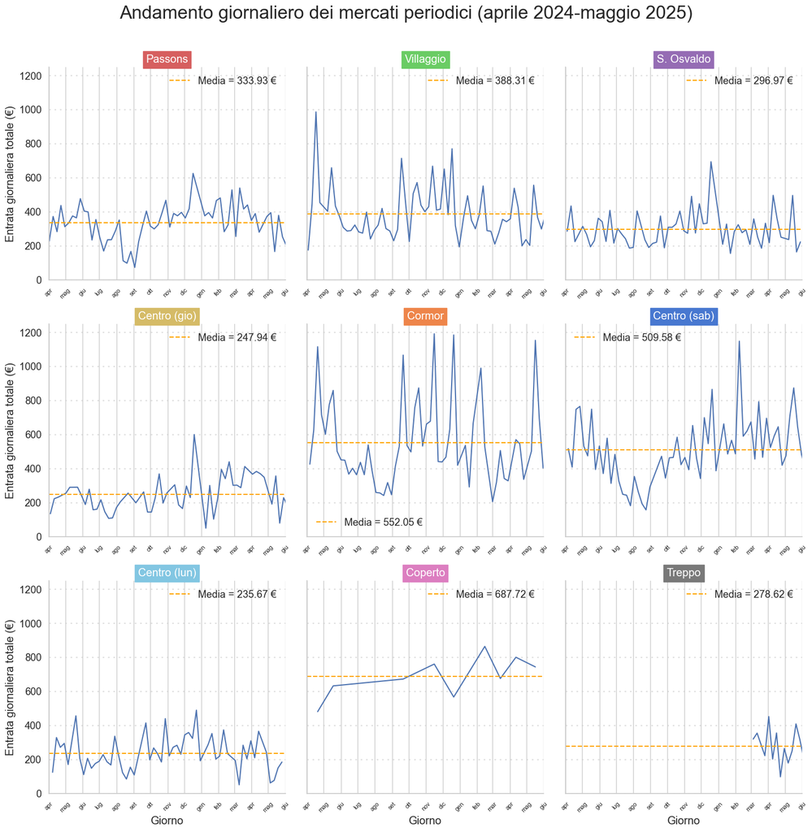

Si vede chiaramente l'alta varianza del mercato del sabato in centro e di quello del parco del Cormor.

Il mercato di San Osvaldo sembra essere immune dall'effetto di stagionalità che invece si intravede abbastanza bene negli altri mercati.

### Mercati preferenziali per categoria di prodotto

Studiamo se ci sono prodotti che vendono meglio su un mercato specifico rispetto agli altri.

Nell'analisi escludiamo il mercato coperto, in cui si vende solo carne, e il mercato di Treppo, per il quale si hanno ancora troppo pochi dati.

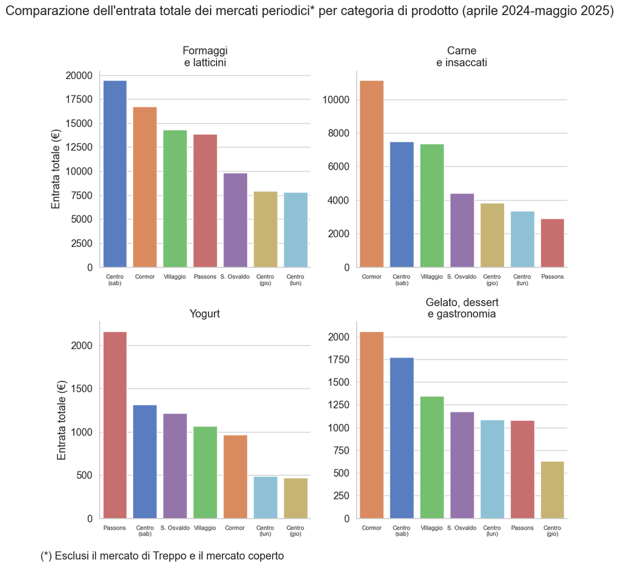

Non ci stupisce che i mercati che vendono di più siano il sabato in Centro e il mercato al parco del Cormor; vediamo che in genere i formaggi vanno meglio in centro e la carne al parco.

Quello che invece stupisce veramente è lo yogurt al mercato di Passons.

L'altra informazione sorprendente che ricaviamo è che i mercati infrasettimanali del centro vanno sempre similmente, tranne con i trasformati dove il giovedì va significativamente peggio del lunedì.

# Conclusioni